# Strava dataset Challenges

Tim Brouwers

2022-12-19

In dit notebook ga ik de strava dataset challenge uitwerken. Hierbij ga ik de aangeboden ritten dataset analyseren en visualiseren.

```r
data <- read.csv("./data/strava.csv", sep = ";") # Convert CSV data to dataframe in R. Use ; as the seperator
```

### Hoeveel verschillende fietsen zijn er gebruikt?

Om antwoord te kunnen geven op deze vraag ga ik een functie genaamd “distinct” toepassen. Door deze functie op het “gear_id” veld toe te passen krijg ik alle unieke fietsen te zien.

Vervolgens pas ik een summarise toe met “n()”. Deze functie geeft het aantal rijen terug. Zo kan ik eenvoudig tot het gewenste eindresultaat komen.

```r
uniqueBicycles <- data %>%
  filter(type == "Ride" || type == "VirtualRide") %>% # Filter on type is Ride or VirtualRide. This is not necessary at the moment since other activities don't have a gear_id
  distinct(gear_id) %>% # Get all unique gear_id's
  summarise(amount=n()) # Get amount of rows left by unique gear id
# Show amount of unique bicycles
uniqueBicycles
```

```
##   amount
## 1     11
```

### Met welke fiets wordt het snelste gefietst?

Om deze vraag te beantwoorden ga ik berekenen wat de gemiddelde snelheid van de fietsen zijn. Hierbij groepeer ik op “gear_id”. Vervolgens maak ik een summary waarbij ik de totale afgelegde afstand deel door de totale beweegtijd van deze fiets. Daarna sorteer ik van hoog naar laag op basis van deze gemiddelde snelheid. Ten slotte maak ik gebruik van ggplot om een inzichtelijke grafiek te maken om deze gegevens uit te lezen. Dit geeft het volgende resultaat:

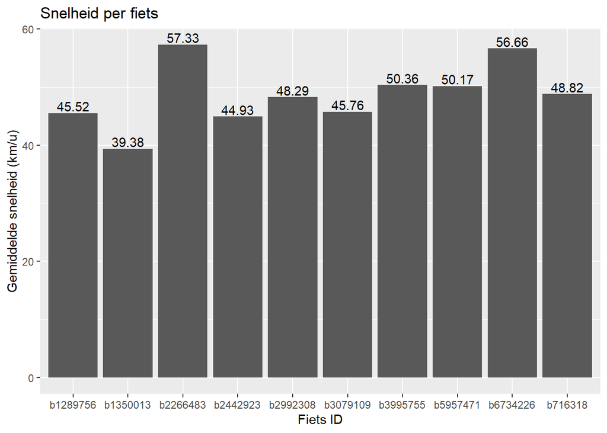

```r
speed <- data %>%
  filter(!is.na(gear_id)) %>% # Remove rows with NA gear_id (non bicycle)
  group_by(gear_id) %>%   # Group on gear_id
  summarise(average_speed=sum(distance) / sum(moving_time)) %>% # Calculate average speed by using sum distance / sum moving time
  arrange(desc(average_speed)) # Arrange from high to low

ggplot(speed, aes(x=gear_id, y=average_speed)) +
  geom_col() +
  labs(x="Fiets ID", y="Gemiddelde snelheid (km/u)", title="Snelheid per fiets") +
  geom_text(aes(label = round(average_speed, digits=2)), vjust = -0.2)
```

Uit deze grafiek blijkt dat de fiets met het gear_id “b2266483” de snelste gemiddelde snelheid heeft met wel 57 km/u.